# Домашнее задание

Тюрнев Иван

Декабрь 2022

[Мой GitHub](https://github.com/XuTPuK99/work_R_1)

# Задание: Виды анализа и R Markdown.

#### Был выдан вариант со следующими анализами:

1. Разведочный
2. Причинно-следственный

##### **Разведочный анализ**

- В качестве примера была рассмотрена [данная статья](https://cyberleninka.ru/article/n/obrabotka-i-razvedochnyy-analiz-chislovyh-massivov-dannyh).

Разведочный анализ зачастую связывают с нахождением общих закономерностей, распределений и аномалий, а также построением начальных моделей, зачастую с использованием инструментов визуализации. При выполнении данный действий мы выявляем в данных значимо отличающиеся значения (выбросы).

В данной статье как раз и применяется с помощью критериев Диксона, r-статистики, Граббса и других. К примеру в алгоритме с критерием Диксона:

> …после ранжирования исходной выборки в порядке не убывания рассчитывают фактическое значение критерия.

А фактическое значение критерия высчитывается с помощью следующей формул:

- $r_{n} = \frac{x_{n} - \tilde{x}}{D_{x}\sqrt{\frac{n-1}{n}}}$ - при подозрении $x_{n}$ на аномальный максимум;
- $r_{1} = \frac{\tilde{x} - x_{1}}{D_{x}\sqrt{\frac{n-1}{n}}}$ - при подозрении $x_{1}$ на аномальный минимум.

В данных формулах:

- $\tilde{x}$ - среднее по выборке (с учётом анализируемого значения);
- $D_{x}$ - дисперсия выборки (с учётом анализируемого значения).

##### **Причинно-следственный анализ**

- В качестве примера была рассмотрена [данная статья](https://elibrary.ru/download/elibrary_35222055_16840035.pdf).

Анализ причинно-следственных связей – это структурированный метод, применяемый для определения возможных причин нежелательного события или проблемы. Он систематизирует возможные влияющие факторы в обобщенные категории таким образом, что позволяет рассматривать все возможные гипотезы.

В данной статье причинно-следственный метод применяется к такой операции как поверка газовых счетчиков

Основная суть метода раскрывается в причинно-следственной диаграмме

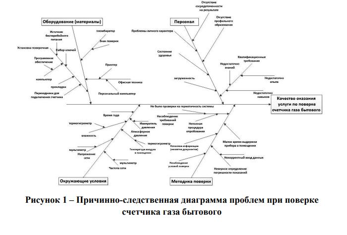

Причём во время такого анализа, для численной оценки использовалась приведённая ниже таблица с массивом данных.

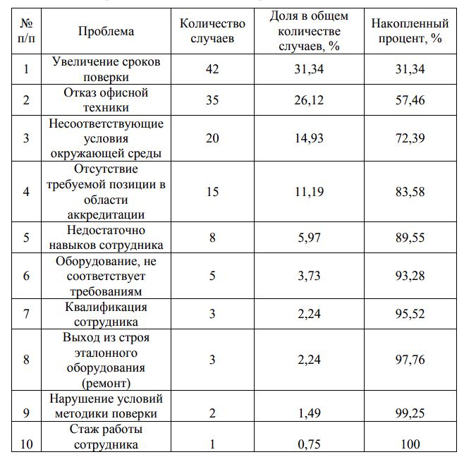